# Case study: number

The Development of Syntagmatic Redundancy in ME

Raquel Montero

September 2023

# 1 Introduction

This file shows the code used to analyse the data in Section 3 of the paper “Sociolinguistic typology meets historical corpus linguistics”; submitted to the Transactions of the Philological Society. Information on how the data was searched, annotated etc. can be found in the Github repository. The following is a guide to the documents that the repository contains:

- Annotation Guidelines: AnnotationGuidelinesSyntRedME.pdf
- CorpusSearch: CorpusSearchSyntRedME_Adjectives.c//CorpusSearchSyntRedME_Quantifiers.c
- Geographical Information about the texts: GeographicsSyntRedME.pdf
- Final data: SyntRedME_Adjectives.cod.ooo//SyntRedME_Quantifiers.cod.ooo

# 2 Data Cleaning

First, we need to load the packages that will be used:

```r
library(gdata, warn.conflicts = FALSE)  # for drop-levels
library(plyr, warn.conflicts = FALSE)
library(dplyr, warn.conflicts = FALSE)
library(ggplot2, warn.conflicts = FALSE)
library(ggrepel, warn.conflicts = FALSE)
library(splines, warn.conflicts = FALSE)
library(MASS, warn.conflicts = FALSE)
library(reshape2, warn.conflicts = FALSE)
library(maps, warn.conflicts = FALSE)
library(viridisLite, warn.conflicts = FALSE)
library(viridis, warn.conflicts = FALSE)  # colors of the map
library(DHARMa, warn.conflicts = FALSE)  # for residuals
library(colorspace)
suppressPackageStartupMessages(library(sjPlot))  # to change the font
```

Then, we import the annotated data, and prepare it for visualization (e.g. eliminating variables that are not needed, converting to numeric the scores, etc.):

```r
## ADJECTIVES DATA:


# Importing the data:

data_agreementadj <- read.delim("Data/SyntRedME_Adjectives.cod.ooo.ooo", header=F, sep=":")

# Naming the columns:
colnames(data_agreementadj) <- c("position",
                                 "agreement",
                                 "Text",
                                 "Year",
                                 "Dialect",
                                 "numsyll",
                                 "animate")

# Eliminate variables not used:
ex.dataadj <- subset(data_agreementadj,
                     position != "z" &
                       position != "multiple"&  # Eliminating cases with multiple adjectives
                       position != "Conjoined" &  # Eliminating cases of conjoined adjectives
                       agreement!= "z"  &
                       agreement!= "french-agree" &  # Eliminating cases with French  morphology
                       agreement != "adverbial-ly" & # Eliminating adjectives formed with -ly
                       agreement != "e-ending" &     # Eliminate adjectives with root ends in -e
                       agreement != "uninflected" & # Eliminate adjectives uninflected in OE
                       Text != "z"  &
                       Year != "z" &
                       Dialect != "z"  &
                       numsyll == "monosyllabic"  # Only monosyllabic adjectives
                     )


## QUANTIFIERS DATA:

# Importing the data:
data_agreementquant <- read.delim("Data/SyntRedME_Quantifiers.cod.ooo.ooo", header=F, sep=":")

# Naming the columns:
colnames(data_agreementquant) <- c("quant",
                                   "agreement",
                                   "Text",
                                   "Year",
                                   "Dialect",
                                   "numsyll")

# Eliminate variables not used:
ex.dataquant <- subset(data_agreementquant,
                         quant != "z" &
                         agreement != "z" &
                         Text != "z" &
                         Year != "z"  &
                         Dialect != "z"  &
                         numsyll == "monosyllabic"
                       )


# droplevels: to drop unused factor levels.
ex.dataadj <- droplevels(ex.dataadj)
ex.dataquant <- droplevels(ex.dataquant)


# years stored as numbers:
ex.dataadj$Year <- as.numeric(as.character(ex.dataadj$Year))
ex.dataquant$Year <- as.numeric(as.character(ex.dataquant$Year))

# create a new column changing the agreement type into a binary variable: (agreement = 1, no agreement = 0)
ex.dataadj$agreement_new <- ifelse(ex.dataadj$agreement == "agreement", 1, 0)
ex.dataadj$agreement_new <- as.numeric(as.character(ex.dataadj$agreement_new)) # change into numberic value
ex.dataquant$agreement_new <- ifelse(ex.dataquant$agreement == "agreement", 1, 0)
ex.dataquant$agreement_new <- as.numeric(as.character(ex.dataquant$agreement_new)) #change into numeric value
```

We then have a look at how much data there is for our data analysis:

```r
table <- table(ex.dataadj$Dialect)
table
```

```
##
##       EM Northern Southern       WM
##      528       78      276      300
```

```r
table1 <- table(ex.dataquant$Dialect)
table1
```

```
##
##       EM Northern Southern       WM
##     1535      272      599      778
```

Calculate the mean agreement per text

```r
plot.data2 <- ddply(ex.dataadj, .(Text, Dialect, Year), summarize, whet = mean(as.numeric(as.character(agreement_new)),
    na.rm = T), n = sum(!is.na(as.numeric(as.character(agreement_new)))))
plot.data2
```

```
##                 Text  Dialect Year       whet   n
## 1             Aelred       EM 1325 0.77777778  18
## 2            Ancrene       WM 1230 0.94736842  57
## 3          Astrolabe       EM 1390 0.83333333   6
## 4           Ayenbyte Southern 1340 0.96969697  66
## 5             Benrul Northern 1425 0.87500000   8
## 6          Boethious       EM 1380 1.00000000  12
## 7         Book-vices       EM 1400 0.87500000   8
## 8               Brut       WM 1400 0.84210526  38
## 9  Capgrave-chrnicle       EM 1460 0.60975610  41
## 10        Chronicles       EM 1150 1.00000000   7
## 11             Cloud       EM 1400 1.00000000   4
## 12            Edmund       WM 1390 1.00000000   2
## 13         Edmund-m4       EM 1450 1.00000000   2
## 14            Edthor Northern 1350 0.80000000   5
```

[output cut: 30 more lines]

```r
plot.data4 <- ddply(ex.dataquant, .(Text, Dialect, Year), summarize, whet = mean(as.numeric(as.character(agreement_new)),
    na.rm = T), n = sum(!is.na(as.numeric(as.character(agreement_new)))))
head(plot.data4)
```

```
##        Text  Dialect Year      whet   n
## 1    Aelred       EM 1325 0.9000000  30
## 2 Aelred-m4       EM 1450 0.9090909  22
## 3   Ancrene       WM 1230 0.9000000 120
## 4 Astrolabe       EM 1390 0.8947368  19
## 5  Ayenbyte Southern 1340 0.9467456 169
## 6    Benrul Northern 1425 0.7222222  54
```

Merging the two data sets:

```r
## First, merge the two data frames:
total <- merge(plot.data2, plot.data4, by = c("Text", "Dialect", "Year"))

colnames(total) <- c("Text", "Dialect", "Year", "adjectives", "nad", "quantifier",
    "nq")


## New column with the differences in the agreement proportion:
total$diff <- total$adjectives - total$quantifier
```

# 3 Data Visualization

## 3.1 Map

First we need to add a column with the coordinates for each text:

```r
# Adding column based on new Coordinates:

#Adding the Latitude:

total4 <- total %>%
  mutate(Longitude = case_when(
    (Text== "medicinis") ~ "-0.56880000",
    (Text== "Norwich") ~ "-0.20312085",
    (Text== "Horses" ) ~ "-1.0318673",
    (Text=="Richard-rolle") ~ "-2.0014878",
    (Text=="Innocencium") ~ "-1.4743217",
    (Text=="Edthor") ~ "-2.2412109",
    (Text=="Mandeville") ~ "0.33441843",
    (Text=="Edmund-m4") ~ "0.0000000",
    (Text=="Gaytry") ~ "-2.2412109",
    (Text=="Capgrave-chrnicle") ~ "1.0000000",
    (Text=="Capgrave-sermon") ~ "0.41325972",
    (Text=="Morte-a") ~ "-1.5536906",
    (Text=="Brut") ~ "-2.9340404",
    (Text=="Kentish-homilies") ~ "-1.8031714",
    (Text=="Royal") ~ "-0.80603102",
    (Text=="Polychronicon") ~ "-2.4498470",
    (Text=="Benrul") ~ "-1.0836749",
    (Text=="Chronicles") ~ "-0.24573507",
    (Text=="Gregory") ~ "-0.60829082",
    (Text=="Cloud") ~ "-1.3818890",
    (Text=="Mirk") ~ "-1.8076144",
    (Text=="Lambeth") ~ "-2.4116106",
    (Text=="Ancrene") ~ "-2.7064436",
    (Text=="Siege-j") ~ "-1.6660928",
    (Text=="Ayenbyte") ~ "1.0814800",
    (Text=="Edmund") ~ "-2.1569555",
    (Text=="Katherine-group") ~ "-2.7064436",
    (Text=="Boethious") ~ "-0.12772404",
    (Text=="Old-testament") ~ "-0.89464405",
    (Text=="Vices") ~ "0.12773182",
    (Text=="Equatorie") ~ "-0.67179476",
    (Text=="Hilton") ~ "-0.22077060",
    (Text=="Kentish-sermons") ~ "0.62063882",
    (Text=="Parson") ~ "-0.12772404",
    (Text=="Trinity") ~ "-1.6118882",
    (Text=="Melibee") ~ "-0.12772404",
    (Text=="Book-vices") ~ "0.11872816",
    (Text=="Astrolabe") ~ "-1.0318673",
    (Text=="wycliffite") ~ "-1.3150252",
    (Text=="Purvey") ~ "-0.12942373",
    (Text=="Reynard") ~ "0.0000000",
    (Text=="Aelred") ~ "-2.3237144",
    (Text=="Aelred-m4") ~ "0.0000000",
    (Text=="Reynes") ~ "1.5482236",
    (Text=="Psalter") ~ "0.0039963911",
    (Text=="New-testament") ~ "-0.27629328",
    (Text=="Kempe") ~ "1.0000000",

    ))


#Adding the Longitude:

total5 <- total4 %>%
  mutate(Latitude = case_when(
    (Text== "medicinis") ~ "53.065628",
    (Text== "Horses" ) ~ "51.453486",
    (Text== "Norwich") ~ "-53.182303",
    (Text=="Richard-rolle") ~ "53.955093",
    (Text=="Innocencium") ~ "51.068150",
    (Text=="Edthor") ~ "54.690768",
    (Text=="Mandeville") ~ "52.376964",
    (Text=="Edmund-m4") ~ "52.505077",
    (Text=="Gaytry") ~ "54.690768",
    (Text=="Capgrave-chrnicle") ~ "52.666667",
    (Text=="Capgrave-sermon") ~ "52.744048",
    (Text=="Morte-a") ~ "52.321306",
    (Text=="Brut") ~ "52.018714",
    (Text=="Kentish-homilies") ~ "50.892692",
    (Text=="Royal") ~ "51.485871",
    (Text=="Polychronicon") ~ "51.688892",
    (Text=="Benrul") ~ "53.962009",
    (Text=="Chronicles") ~ "52.566821",
    (Text=="Gregory") ~ "51.357801",
    (Text=="Cloud") ~ "52.560221",
    (Text=="Mirk") ~ "53.029131",
    (Text=="Lambeth") ~ "52.255453",
    (Text=="Ancrene") ~ "52.370931",
    (Text=="Siege-j") ~ "52.039927",
    (Text=="Ayenbyte") ~ "51.280552",
    (Text=="Edmund") ~ "52.210949",
    (Text=="Katherine-group") ~ "52.370931",
    (Text=="Boethious") ~ "51.507407",
    (Text=="Old-testament") ~ "51.783499",
    (Text=="Vices") ~ "51.742427",
    (Text=="Equatorie") ~ "52.796561",
    (Text=="Hilton") ~ "52.161753",
    (Text=="Kentish-sermons") ~ "51.246812",
    (Text=="Parson") ~ "51.507407",
    (Text=="Trinity") ~ "51.563236",
    (Text=="Melibee") ~ "51.507407",
    (Text=="Book-vices") ~ "51.859491",
    (Text=="Astrolabe") ~ "51.507407",
    (Text=="wycliffite") ~ "53.063272",
    (Text=="Purvey") ~ "52.178413",
    (Text=="Reynard") ~ "52.505077",
    (Text=="Aelred") ~ "52.255726",
    (Text=="Aelred-m4") ~ "52.505077",
    (Text=="Reynes") ~ "52.632148",
    (Text=="Psalter") ~ "51.564752",
    (Text=="New-testament") ~ "52.162668",
    (Text=="Kempe") ~ "52.666667",
    ))


## The coordinates are stored as characters but we need the numbers:

total5$Latitude <- as.numeric(as.character(total5$Latitude))
total5$Longitude <- as.numeric(as.character(total5$Longitude))
```

Create the map:

```r
## Creating the map:

worldmap = map_data("world")
knitr::kable(head(worldmap, 20))
```

|  | long | lat | group | order | region | subregion |
| --- | --- | --- | --- | --- | --- | --- |
| 1 | -69.89912 | 12.45200 | 1 | 1 | Aruba | NA |
| 2 | -69.89571 | 12.42300 | 1 | 2 | Aruba | NA |
| 3 | -69.94219 | 12.43853 | 1 | 3 | Aruba | NA |
| 4 | -70.00415 | 12.50049 | 1 | 4 | Aruba | NA |
| 5 | -70.06612 | 12.54697 | 1 | 5 | Aruba | NA |
| 6 | -70.05088 | 12.59707 | 1 | 6 | Aruba | NA |
| 7 | -70.03511 | 12.61411 | 1 | 7 | Aruba | NA |
| 8 | -69.97314 | 12.56763 | 1 | 8 | Aruba | NA |
| 9 | -69.91181 | 12.48047 | 1 | 9 | Aruba | NA |
| 10 | -69.89912 | 12.45200 | 1 | 10 | Aruba | NA |
| 12 | 74.89131 | 37.23164 | 2 | 12 | Afghanistan | NA |
| 13 | 74.84023 | 37.22505 | 2 | 13 | Afghanistan | NA |
| 14 | 74.76738 | 37.24917 | 2 | 14 | Afghanistan | NA |
| 15 | 74.73896 | 37.28564 | 2 | 15 | Afghanistan | NA |
| 16 | 74.72666 | 37.29072 | 2 | 16 | Afghanistan | NA |
| 17 | 74.66895 | 37.26670 | 2 | 17 | Afghanistan | NA |
| 18 | 74.55899 | 37.23662 | 2 | 18 | Afghanistan | NA |
| 19 | 74.37217 | 37.15771 | 2 | 19 | Afghanistan | NA |
| 20 | 74.37617 | 37.13735 | 2 | 20 | Afghanistan | NA |
| 21 | 74.49796 | 37.05722 | 2 | 21 | Afghanistan | NA |

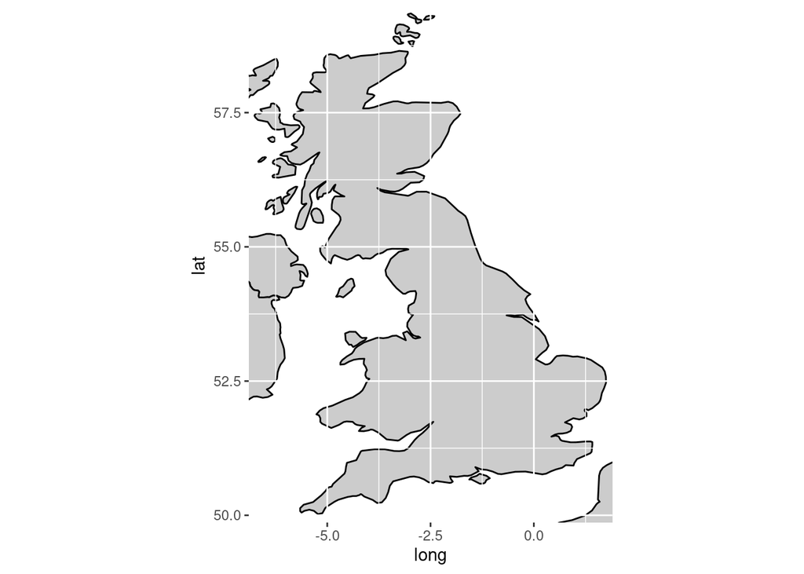

```r
ggplot() + geom_polygon(data = worldmap, aes(x = long, y = lat, group = group), fill = "gray80",
    color = "black") + coord_fixed(ratio = 1.3, xlim = c(-6.5, 1.5), ylim = c(50.3,
    59)) + theme(panel.background = element_rect(fill = NA), panel.ontop = TRUE)
```

Add the information to the map:

```r
# windowsFonts('Garamond' = windowsFont('Garamond'))

set_theme(base = theme_bw(), title.size = 1.4, axis.title.size = 1.3, axis.textsize = 1.1,
    axis.textcolor = "black", axis.title.color = "black", legend.size = 1.2, legend.title.size = 1.4,
    geom.label.size = 3)

worldmap = map_data("world")
knitr::kable(head(worldmap, 20))
```

|  | long | lat | group | order | region | subregion |
| --- | --- | --- | --- | --- | --- | --- |
| 1 | -69.89912 | 12.45200 | 1 | 1 | Aruba | NA |
| 2 | -69.89571 | 12.42300 | 1 | 2 | Aruba | NA |
| 3 | -69.94219 | 12.43853 | 1 | 3 | Aruba | NA |
| 4 | -70.00415 | 12.50049 | 1 | 4 | Aruba | NA |
| 5 | -70.06612 | 12.54697 | 1 | 5 | Aruba | NA |
| 6 | -70.05088 | 12.59707 | 1 | 6 | Aruba | NA |
| 7 | -70.03511 | 12.61411 | 1 | 7 | Aruba | NA |
| 8 | -69.97314 | 12.56763 | 1 | 8 | Aruba | NA |
| 9 | -69.91181 | 12.48047 | 1 | 9 | Aruba | NA |
| 10 | -69.89912 | 12.45200 | 1 | 10 | Aruba | NA |
| 12 | 74.89131 | 37.23164 | 2 | 12 | Afghanistan | NA |
| 13 | 74.84023 | 37.22505 | 2 | 13 | Afghanistan | NA |
| 14 | 74.76738 | 37.24917 | 2 | 14 | Afghanistan | NA |
| 15 | 74.73896 | 37.28564 | 2 | 15 | Afghanistan | NA |
| 16 | 74.72666 | 37.29072 | 2 | 16 | Afghanistan | NA |
| 17 | 74.66895 | 37.26670 | 2 | 17 | Afghanistan | NA |
| 18 | 74.55899 | 37.23662 | 2 | 18 | Afghanistan | NA |
| 19 | 74.37217 | 37.15771 | 2 | 19 | Afghanistan | NA |
| 20 | 74.37617 | 37.13735 | 2 | 20 | Afghanistan | NA |
| 21 | 74.49796 | 37.05722 | 2 | 21 | Afghanistan | NA |

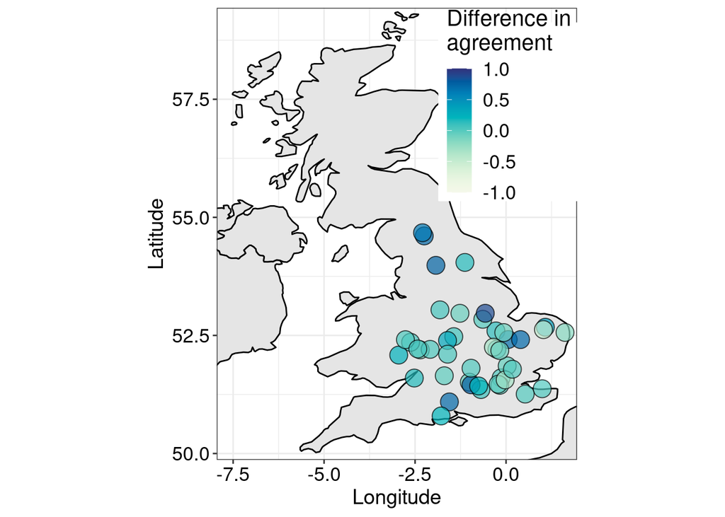

```r
# set RNG seed so jitter is always in the same place
set.seed(3242)

mapengland2 <- ggplot() + geom_polygon(data = worldmap, aes(x = long, y = lat, group = group),
    fill = "grey90", color = "black") + coord_fixed(ratio = 1.3, xlim = c(-7.5, 1.5),
    ylim = c(50.3, 59)) + geom_point(data = total5, aes(x = Longitude, y = Latitude,
    fill = diff), alpha = I(0.7), size = 5.5, color = "black", pch = 21, position = position_jitter(h = 0.1,
    w = 0.1)) + scale_fill_continuous_sequential(palette = "GnBu", limits = c(-1,
    1)) + theme(legend.position = c(0.82, 0.77)) + labs(x = "Longitude", y = "Latitude",
    fill = expression(paste("Difference in \nagreement")))

mapengland2
```

```r
ggsave(mapengland2, file = "Figure1.pdf", width = 8, height = 8)
```

## 3.2 Barplots

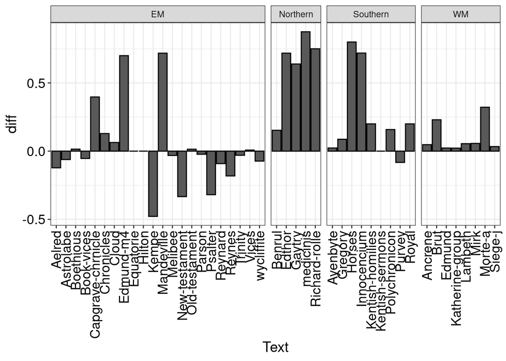

```r
# Barplots by dialect and Text:

barplot1 <- ggplot(data = total5, aes(x = Text, y = diff)) + geom_bar(stat = "identity") +
    facet_grid(. ~ Dialect, scales = "free", space = "free") + theme(axis.text.x = element_text(angle = 90,
    vjust = 0.5, hjust = 1))

barplot1
```

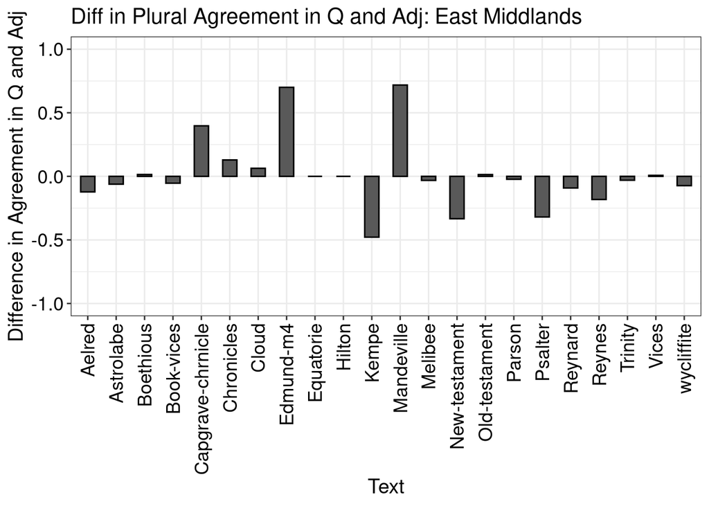

```r
# Individual plots
total5EM <- subset(total5, Dialect == "EM")
barplotEM <- ggplot(data = total5EM, aes(x = Text, y = diff)) + geom_bar(stat = "identity",
    width = 0.5) + theme(axis.text.x = element_text(angle = 90, vjust = 0.5, hjust = 1)) +
    ggtitle("Diff in Plural Agreement in Q and Adj: East Middlands") + ylab("Difference in Agreement in Q and Adj") +
    ylim(-1, 1)
barplotEM
```

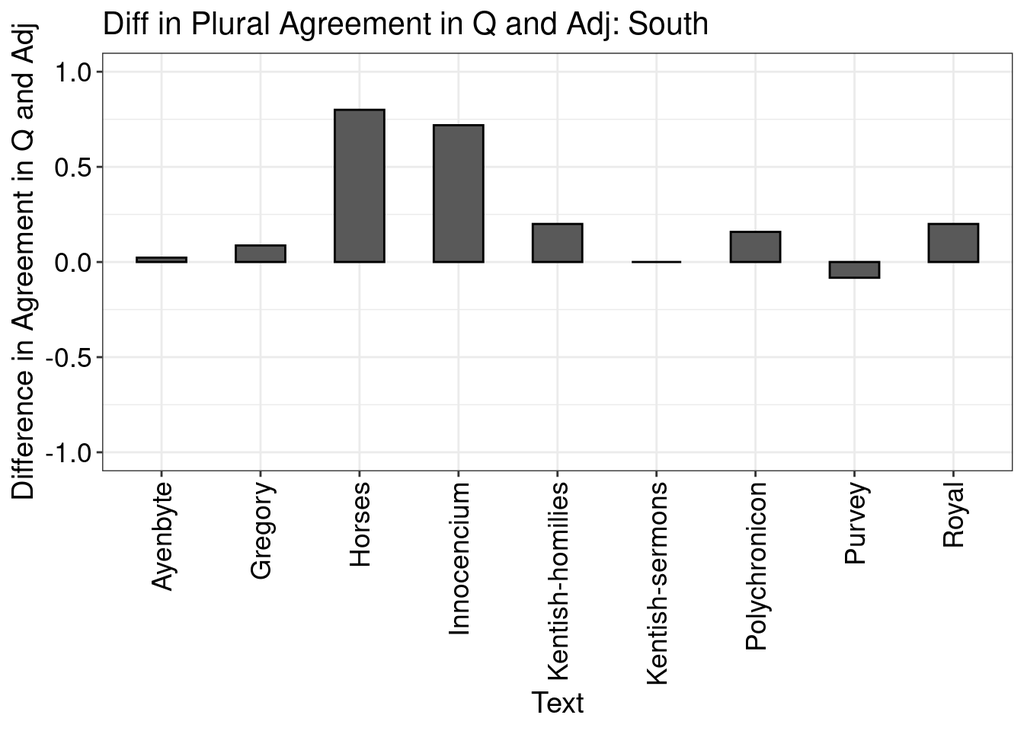

```r
##############
total5S <- subset(total5, Dialect == "Southern")
barplotS <- ggplot(data = total5S, aes(x = Text, y = diff)) + geom_bar(stat = "identity",
    width = 0.5) + theme(axis.text.x = element_text(angle = 90, vjust = 0.5, hjust = 1)) +
    ggtitle("Diff in Plural Agreement in Q and Adj: South") + ylab("Difference in Agreement in Q and Adj") +
    ylim(-1, 1)
barplotS
```

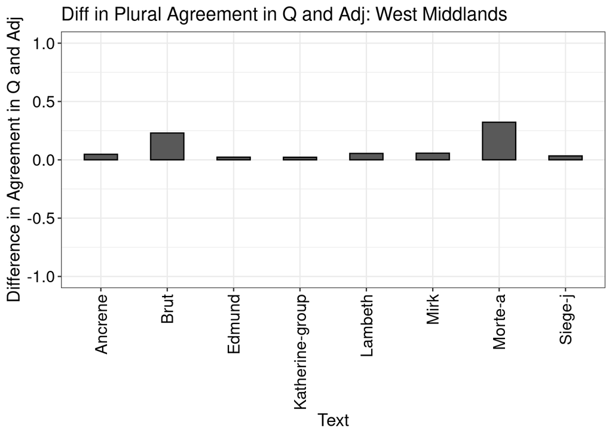

```r
#############
total5WM <- subset(total5, Dialect == "WM")
barplotWM <- ggplot(data = total5WM, aes(x = Text, y = diff)) + geom_bar(stat = "identity",
    width = 0.5) + theme(axis.text.x = element_text(angle = 90, vjust = 0.5, hjust = 1)) +
    ggtitle("Diff in Plural Agreement in Q and Adj: West Middlands") + ylab("Difference in Agreement in Q and Adj") +
    ylim(-1, 1)
barplotWM
```

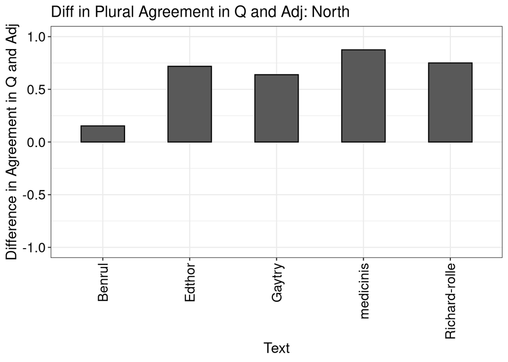

```r
total5N <- subset(total5, Dialect == "Northern")
barplotN <- ggplot(data = total5N, aes(x = Text, y = diff)) + geom_bar(stat = "identity",
    width = 0.5) + theme(axis.text.x = element_text(angle = 90, vjust = 0.5, hjust = 1)) +
    ggtitle("Diff in Plural Agreement in Q and Adj: North") + ylab("Difference in Agreement in Q and Adj") +
    ylim(-1, 1)
barplotN
```

```r
totalm <- total5 %>%
    mutate(Period = case_when((Text == "medicinis") ~ "M4", (Text == "Horses") ~
        "M3", (Text == "Richard-rolle") ~ "M2", (Text == "Norwich") ~ "M3", (Text ==
        "Innocencium") ~ "M4", (Text == "Edthor") ~ "M3", (Text == "Mandeville") ~
        "M3", (Text == "Edmund-m4") ~ "M4", (Text == "Gaytry") ~ "M3", (Text == "Capgrave-chrnicle") ~
        "M4", (Text == "Capgrave-sermon") ~ "M4", (Text == "Morte-a") ~ "M4", (Text ==
        "Brut") ~ "M3", (Text == "Kentish-homilies") ~ "M1", (Text == "Royal") ~
        "M3", (Text == "Polychronicon") ~ "M3", (Text == "Benrul") ~ "M3", (Text ==
        "Chronicles") ~ "M1", (Text == "Gregory") ~ "M4", (Text == "Cloud") ~ "M3",
        (Text == "Mirk") ~ "M3", (Text == "Lambeth") ~ "M1", (Text == "Ancrene") ~
            "M1", (Text == "Siege-j") ~ "M4", (Text == "Ayenbyte") ~ "M2", (Text ==
            "Edmund") ~ "M3", (Text == "Katherine-group") ~ "M1", (Text == "Boethious") ~
            "M3", (Text == "Old-testament") ~ "M3", (Text == "Vices") ~ "M1", (Text ==
            "Equatorie") ~ "M3", (Text == "Hilton") ~ "M3", (Text == "Kentish-sermons") ~
            "M2", (Text == "Parson") ~ "M3", (Text == "Trinity") ~ "M1", (Text ==
            "Melibee") ~ "M3", (Text == "Book-vices") ~ "M3", (Text == "Astrolabe") ~
            "M3", (Text == "wycliffite") ~ "M3", (Text == "Purvey") ~ "M3", (Text ==
            "Reynard") ~ "M4", (Text == "Aelred") ~ "M2", (Text == "Reynes") ~ "M4",
        (Text == "Psalter") ~ "M2", (Text == "New-testament") ~ "M3", (Text == "Kempe") ~
            "M4", ))
```

# 4 Statistical Analysis

## 4.1 Linear Regression Model (lm)

```r
total$diff <- as.numeric(total$diff)

# Testing the effect of difference in agreement: linear model
ex.fittotal <- lm(diff ~ Dialect, data = total)
summary(ex.fittotal)
```

```
##
## Call:
## lm(formula = diff ~ Dialect, data = total)
##
## Residuals:
##      Min       1Q   Median       3Q      Max
## -0.48938 -0.08868 -0.04176  0.06209  0.70709
##
## Coefficients:
##                 Estimate Std. Error t value Pr(>|t|)
## (Intercept)      0.01113    0.05720   0.195   0.8467
## DialectNorthern  0.61595    0.13291   4.634 3.77e-05 ***
## DialectSouthern  0.22270    0.10615   2.098   0.0423 *
## DialectWM        0.08744    0.11076   0.789   0.4345
## ---
## Signif. codes:  0 '***' 0.001 '**' 0.01 '*' 0.05 '.' 0.1 ' ' 1
##
## Residual standard error: 0.2683 on 40 degrees of freedom
## Multiple R-squared:  0.3635, Adjusted R-squared:  0.3158
## F-statistic: 7.616 on 3 and 40 DF,  p-value: 0.0003837
```

```r
# using South as the reference level:
total$Dialect <- relevel(factor(total$Dialect), ref = 3)
ex.fittotal <- lm(diff ~ Dialect, data = total)
summary(ex.fittotal)
```

```
##
## Call:
## lm(formula = diff ~ Dialect, data = total)
##
## Residuals:
##      Min       1Q   Median       3Q      Max
## -0.48938 -0.08868 -0.04176  0.06209  0.70709
##
## Coefficients:
##                 Estimate Std. Error t value Pr(>|t|)
## (Intercept)      0.23382    0.08942   2.615   0.0125 *
## DialectEM       -0.22270    0.10615  -2.098   0.0423 *
## DialectNorthern  0.39326    0.14964   2.628   0.0121 *
## DialectWM       -0.13526    0.13036  -1.038   0.3057
## ---
## Signif. codes:  0 '***' 0.001 '**' 0.01 '*' 0.05 '.' 0.1 ' ' 1
##
## Residual standard error: 0.2683 on 40 degrees of freedom
## Multiple R-squared:  0.3635, Adjusted R-squared:  0.3158
## F-statistic: 7.616 on 3 and 40 DF,  p-value: 0.0003837
```

## 4.2 Test of residuals (DHARMa)

```r
# DHARMa package:

simulationOutput <- simulateResiduals(fittedModel = ex.fittotal, plot = F)
residuals(simulationOutput)
```

```
##  [1] 0.268 0.436 0.408 0.220 0.052 0.492 0.380 0.704 0.928 0.644 0.592 0.348
## [13] 0.992 0.660 0.504 0.536 0.256 0.500 0.964 0.968 0.360 0.040 0.472 0.208
## [25] 0.420 0.996 0.836 0.404 0.412 0.848 0.068 0.524 0.444 0.380 0.136 0.120
## [37] 0.308 0.216 0.680 0.456 0.436 0.392 0.456 0.348
```

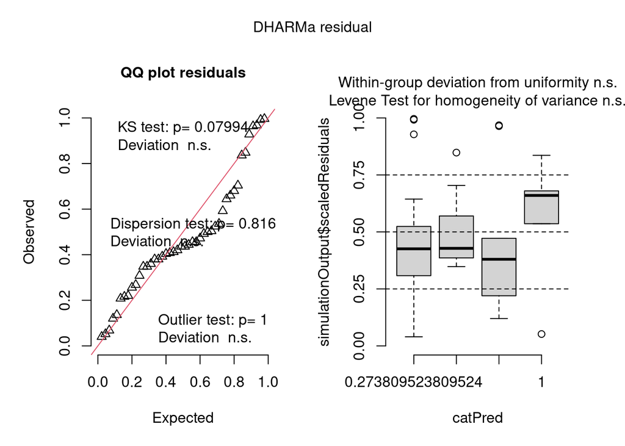

```r
plot(simulationOutput)
```